# Homework #4

Darien Lozon

February 14, 2019

### **1. Fit a logistic regression model that assumes the probability of success is an additive function of variables x1 and x2.**

```r
setwd("C:/Users/dnl0009/Google Drive/SP19 Courses/WMAN633/")
data <- read.csv("Homework 4 Data.csv")
fit <- glm(y~x1+x2,binomial,data); summary(fit)
```

```
##
## Call:
## glm(formula = y ~ x1 + x2, family = binomial, data = data)
##
## Deviance Residuals:
##      Min        1Q    Median        3Q       Max
## -1.43687  -1.00592   0.01992   1.00818   1.50526
##
## Coefficients:
##             Estimate Std. Error z value Pr(>|z|)
## (Intercept)   0.5948     0.3950   1.506   0.1321
## x1           -0.1680     0.3648  -0.460   0.6452
## x2b          -0.9679     0.4136  -2.340   0.0193 *
## ---
## Signif. codes:  0 '***' 0.001 '**' 0.01 '*' 0.05 '.' 0.1 ' ' 1
##
## (Dispersion parameter for binomial family taken to be 1)
##
##     Null deviance: 138.63  on 99  degrees of freedom
## Residual deviance: 132.59  on 97  degrees of freedom
## AIC: 138.59
##
## Number of Fisher Scoring iterations: 4
```

### **2. Interpret the effect of variable x1 on the log odds of success. Verify your interpretation in R.**

The regression coefficient for x1 is the log odds ratio regarding a 1-unit change in the predictor.

```r
b <- coef(fit)
zilch <- plogis(b[1] + b[3]) # x1 = 0; need the plogis function to bind to (0,1)
one <- plogis(b[1] + b[2] + b[3]) # x1 = 1
log((one/(1-one)) / (zilch/(1-zilch))) # Log odds ratio
```

```
## (Intercept)
##   -0.167976
```

```r
summary(fit)[['coefficients']]['x1','Estimate'] # Woo, they're the same. :)
```

```
## [1] -0.167976
```

### **3. Interpret the effect of variable x2 on the log odds of success. Verify your interpretation in R.**

The regression coefficient for x2 is the difference in the log odds ratio between categories A and B.

```r
pA <- plogis(b[1] + b[2]) #x2 = 0
pB <- plogis(b[1] + b[2] + b[3]) #x2 = 1
log((pB/(1-pB))/(pA/(1-pA)))
```

```
## (Intercept)
##  -0.9679244
```

```r
summary(fit)[['coefficients']]['x2b','Estimate'] # Woo, they're the same. :)
```

```
## [1] -0.9679244
```

### **4. Duplicate the Wald Test and p-values for variables x1 and x2 performed by the glm() function. Do you reject or fail to reject your null hypothesis?**

**Wald test for x1:**

```r
b1 <- b[2]
se <- summary(fit)[['coefficients']]['x1','Std. Error']
Wald1 <- b1/se; Wald1 # Calculate and call test statistic
```

```
##         x1
## -0.4604971
```

```r
summary(fit)[['coefficients']]['x1','z value'] # Compare to model output
```

```
## [1] -0.4604971
```

**P-value for x1:**

```r
# P-value for x1
p1 <- 2 * pnorm(-1 * abs(Wald1), mean=0, sd=1); p1 # Calculate and call p-value
```

```
##        x1
## 0.6451594
```

```r
summary(fit)[['coefficients']]['x1','Pr(>|z|)'] # Compare
```

```
## [1] 0.6451594
```

With a p-value of 0.645, it is clear that the null hypothesis will *not* be rejected.

**Wald test for x2:**

```r
b2 <- b[3]
se <- summary(fit)[['coefficients']]['x2b','Std. Error']
Wald2 <- b2/se; Wald2
```

```
##       x2b
## -2.340366
```

```r
summary(fit)[['coefficients']]['x2b','z value']
```

```
## [1] -2.340366
```

**P-value for x2:**

```r
p2 <- 2 * pnorm(-1 * abs(Wald2), mean=0, sd=1); p2
```

```
##        x2b
## 0.01926485
```

```r
summary(fit)[['coefficients']]['x2b','Pr(>|z|)']
```

```
## [1] 0.01926485
```

With a p-value of 0.019, there is a bit of gray area as to whether or not the null hypothesis should be rejected. With an alpha value of 0.05, the null hypothesis certainly would be rejected; however, with an alpha value of 0.01, the interpretation is a bit less clear.

### **5. Predict and plot the mean probability of success over the range of values of x1.**

**Prediction**

```r
y <- b[1] + b[2] * mean(data$x1) + b[3]; y
```

```
## (Intercept)
##  -0.5041695
```

```r
yexp <- exp(y) / (1+exp(y)); yexp
```

```
## (Intercept)
##   0.3765613
```

```r
plogis(y) # Same. Yay!
```

```
## (Intercept)
##   0.3765613
```

**Plot**

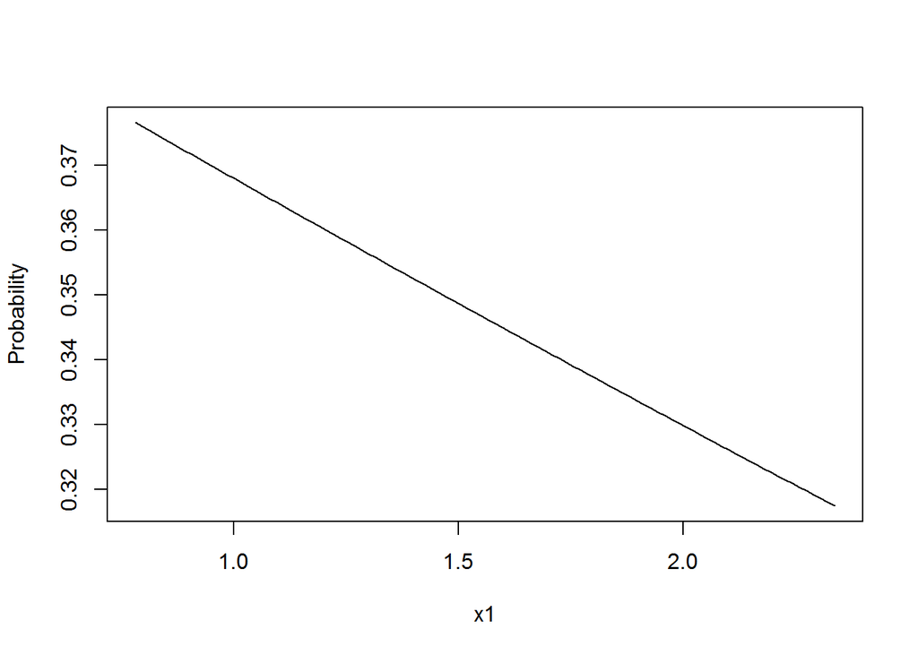

```r
x1 <- seq(mean(data$x1),max(data$x1),length.out=100)
ypred <- plogis(b[1] + b[2] * x1 + b[3]) # Category B
plot(x=x1,y=ypred,type='l',xlab='x1',ylab='Probability')
```

This plot doesn’t look very sigmoidal. Prior to looking at the lecture slides, I got the following plot and like this one better.

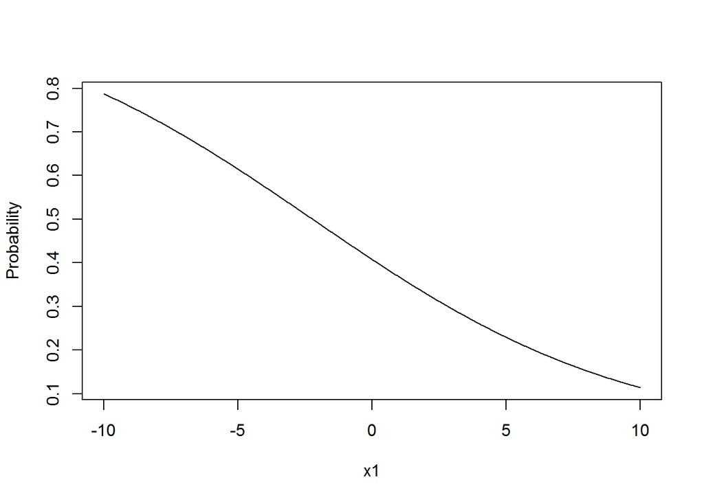

```r
x1 <- seq(-10,10,length.out=1000)
ypred <- plogis(b[1] + b[2] * x1 + b[3]) # Category B
plot(x=x1,y=ypred,type='l',xlab='x1',ylab='Probability')
```

*Le fin.*